# R_Project_2

2025-11-05

# Анализ данных о распространении диабета среди 4000 пациентов

В нашем распоряжении оказался набор данных о пациентах: их клинической истории, образе жизни, биохимических показателях, социальных компонентах их жизни. Весьма исчерпывающий объем информации, представленный в имеющеся датасете позволяет исследовать основные предикторы развития диабета, а так же изучить распределение этого заболевания среди населения и зависимость его возникновения от разнообразных факторов.

# Описание данных

В полученном датасете представлена следующая информация о пациентах:

- **Возраст и пол**
- **Сведения о социальных показателях**: национальность, уровень образования и доход, статус трудоустройства. Категориальные данные.
- **Информация об образе жизни**: курение, потребление алкоголя, физическая активность, диета, количество сна, экранное время.
- **Клиническая история**: наличие диабета в семье, наличие проблем с кровяным давлением или болезней сердца и сосудов.
- **Антропометрические показатели**: ИМТ и отношение размера талии к бедрам.
- **Клинические и биохимические показатели**: кровяное давление, ЧСС, уровень холестерола, триглицеридов, глюкозы, инсулина, hba1c
- Также представлены сведения о рисках развития диабета, типе заболевания и наличии диабета в целом.

# Проверка данных

## Работа с пропущенными значениями

```r
table(is.na(data))
```

```
##
##  FALSE
## 124000
```

Нам повезло, пропущенных значений в наборе данных нет.

## Проверка типов переменных и устранение недочетов

При загрузке датафрейма типы данных были установлены автоматически:

| Переменная | Тип данных |
| --- | --- |
| age | numeric |
| gender | character |
| ethnicity | character |
| education_level | character |
| income_level | character |
| employment_status | character |
| smoking_status | character |
| alcohol_consumption_per_week | numeric |
| physical_activity_minutes_per_week | numeric |
| diet_score | numeric |
| sleep_hours_per_day | numeric |
| screen_time_hours_per_day | numeric |
| family_history_diabetes | numeric |
| hypertension_history | numeric |
| cardiovascular_history | numeric |
| bmi | numeric |
| waist_to_hip_ratio | numeric |
| systolic_bp | numeric |
| diastolic_bp | numeric |
| heart_rate | numeric |
| cholesterol_total | numeric |
| hdl_cholesterol | numeric |
| ldl_cholesterol | numeric |
| triglycerides | numeric |
| glucose_fasting | numeric |
| glucose_postprandial | numeric |
| insulin_level | numeric |
| hba1c | numeric |
| diabetes_risk_score | numeric |
| diabetes_stage | character |
| diagnosed_diabetes | numeric |

Переменные, которые являются категориальными, оказались либо строковыми, либо численными. Перед приведением их к факторам убедимся, что среди категориальных данных нет ошибок или опечаток

```
## $gender
## [1] "Female" "Male"   "Other"
##
## $ethnicity
## [1] "Hispanic" "White"    "Black"    "Asian"    "Other"
##
## $education_level
## [1] "Graduate"     "Highschool"   "Postgraduate" "No formal"
##
## $income_level
## [1] "Middle"       "Lower-Middle" "Upper-Middle" "Low"          "High"
##
## $employment_status
## [1] "Employed"   "Student"    "Retired"    "Unemployed"
##
## $smoking_status
## [1] "Never"   "Current" "Former"
##
## $family_history_diabetes
## [1] 1 0
##
## $hypertension_history
## [1] 0 1
##
## $cardiovascular_history
## [1] 0 1
##
## $diabetes_stage
## [1] "Type 2"       "No Diabetes"  "Pre-Diabetes" "Gestational"  "Type 1"
##
## $diagnosed_diabetes
## [1] 1 0
```

С данными все хорошо, спокойно присваиваем им факторный тип.

## Работа с выбросами

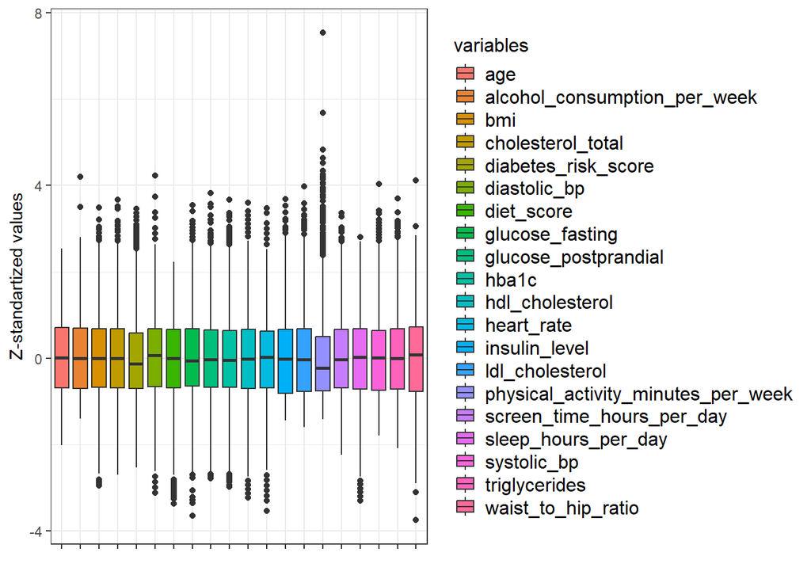

Ввиду разных масштабов имеющихся числовых данных было принято решение провести Z-стандартизацию значений для упрощения восприятия визуализации выбросов, представленной выше.

В глаза бросается самый высокий выброс в переменной `physical activity`, однако если посмотреть на его значение, то станет ясно, что этот пациент занимается физ. нагрузками около 12 часов в неделю, что может быть вполне реалистично. Этот выброс соответствует пациентке 39 лет, курящей и употребляющей алкоголь в среднем 5 раз в неделю, с индексом массы тела 29.9 и диагностированным диабетом.

Остальные значения, оказавшиеся за пределами межквартильного размаха, также являются реалистичными.

| Age | Gender | Smoking | Alcohol Consumption per Week | Physical activity, min/week | Diagnosed Diabetes | Diabetes Stage |
| --- | --- | --- | --- | --- | --- | --- |
| 39 | Female | Current | 5 | 751 | yes | Type 2 |

Таким образом, в имеющемся наборе данных не было обнаружен выбросов, похожих на ошибки наблюдений. Мы проверили наличие отсутствующих значений и выбросов, а также привели все переменные к надлежащим типам данных. Можем ознакомиться с базовыми описательными статистиками и приступать к проверке гипотез.

| Variables | mean | sd | median | min | max |
| --- | --- | --- | --- | --- | --- |
| age | 49.82 | 15.83 | 50.00 | 18.00 | 90.00 |
| alcohol_consumption_per_week | 2.00 | 1.43 | 2.00 | 0.00 | 8.00 |
| physical_activity_minutes_per_week | 118.97 | 83.92 | 100.00 | 0.00 | 751.00 |
| diet_score | 6.02 | 1.79 | 6.00 | 0.00 | 10.00 |
| sleep_hours_per_day | 6.97 | 1.08 | 7.00 | 3.40 | 10.00 |
| screen_time_hours_per_day | 5.97 | 2.45 | 5.90 | 0.50 | 14.20 |
| bmi | 25.62 | 3.61 | 25.60 | 15.00 | 38.20 |
| waist_to_hip_ratio | 0.86 | 0.05 | 0.86 | 0.68 | 1.05 |
| systolic_bp | 115.78 | 14.41 | 116.00 | 90.00 | 174.00 |
| diastolic_bp | 75.41 | 8.17 | 76.00 | 50.00 | 110.00 |
| heart_rate | 69.77 | 8.41 | 70.00 | 40.00 | 99.00 |
| cholesterol_total | 187.13 | 32.37 | 187.00 | 100.00 | 306.00 |
| hdl_cholesterol | 54.12 | 10.24 | 54.00 | 21.00 | 91.00 |
| ldl_cholesterol | 103.93 | 33.72 | 103.00 | 50.00 | 238.00 |
| triglycerides | 121.11 | 43.73 | 121.00 | 30.00 | 283.00 |
| glucose_fasting | 109.73 | 13.61 | 109.00 | 60.00 | 158.00 |
| glucose_postprandial | 155.82 | 30.89 | 155.00 | 70.00 | 274.00 |
| insulin_level | 9.12 | 4.93 | 9.02 | 2.00 | 27.27 |
| hba1c | 6.40 | 0.81 | 6.36 | 4.00 | 9.37 |
| diabetes_risk_score | 29.76 | 9.01 | 28.60 | 6.90 | 60.90 |

```
##     gender        ethnicity        education_level       income_level
##  Female:1946   Asian   : 463   Graduate    :1387   High        : 177
##  Male  :1980   Black   : 675   Highschool  :1830   Low         : 595
##  Other :  74   Hispanic: 768   No formal   : 191   Lower-Middle:1007
##                Other   : 223   Postgraduate: 592   Middle      :1430
##                White   :1871                       Upper-Middle: 791
##   employment_status smoking_status family_history_diabetes hypertension_history
##  Employed  :2369    Current: 812   no :3209                no :3019
##  Retired   : 887    Former : 797   yes: 791                yes: 981
##  Student   : 221    Never  :2391
##  Unemployed: 523
##
##  cardiovascular_history      diabetes_stage diagnosed_diabetes
##  no :3651               Gestational :  14   no :2000
##  yes: 349               No Diabetes : 390   yes:2000
##                         Pre-Diabetes:1596
##                         Type 1      :   8
##                         Type 2      :1992
```

# Проверка гипотез

## Гипотеза 1

## Гипотеза 2

### Зависит ли уровень инсулина в крови пациента от социо-экономических факторов в жизни пациента?

Известно, что [повышенный уровень инсулина является одной из предпосылок диабета](https://pubmed.ncbi.nlm.nih.gov/11118012/). Если среди социальных факторов удастся выявить предикторы повышенного уровня инсулина, то пациенты, оказавшиеся в группе риска, получат возможность предпринять своевременные меры и предотвратить развитие заболевания.

Нулевая гипотеза: социальные факторы в жизни пациента не влияют на уровень инсулина и искать предикторы нужно в другой группе параметров. Альтернативная гипотеза: социальные факторы оказывают эффект на уровень инсулина у пациентов.

### Выбор модели и подходящих параметров

Для начала определимся с выбранными предикторами. В рамках первой проверки построим модель со следующими предикторами: `ethnicity`, `education_level`, `income_level`, `employment_status`.

Зависимость уровня инсулина от социальных предикторов. ANOVA

| Predictors | Sum Sq | Df | F value | Pr(>F) |
| --- | --- | --- | --- | --- |
| ethnicity | 73.81507 | 4 | 0.7583998 | 0.5522839 |
| education_level | 10.22336 | 3 | 0.1400507 | 0.9360424 |
| income_level | 158.49894 | 4 | 1.6284691 | 0.1641494 |
| employment_status | 98.79700 | 3 | 1.3534296 | 0.2551917 |
| Residuals | 96,965.03508 | 3,985 |  |  |

### Проверка допущений

Проверка предикторов на мультиколлинеарность

| Predictors | GVIF | Df | GVIF^(1/(2*Df)) |
| --- | --- | --- | --- |
| ethnicity | 1.010710 | 4 | 1.001333 |
| education_level | 1.007336 | 3 | 1.001219 |
| income_level | 1.015603 | 4 | 1.001937 |
| employment_status | 1.010051 | 3 | 1.001668 |

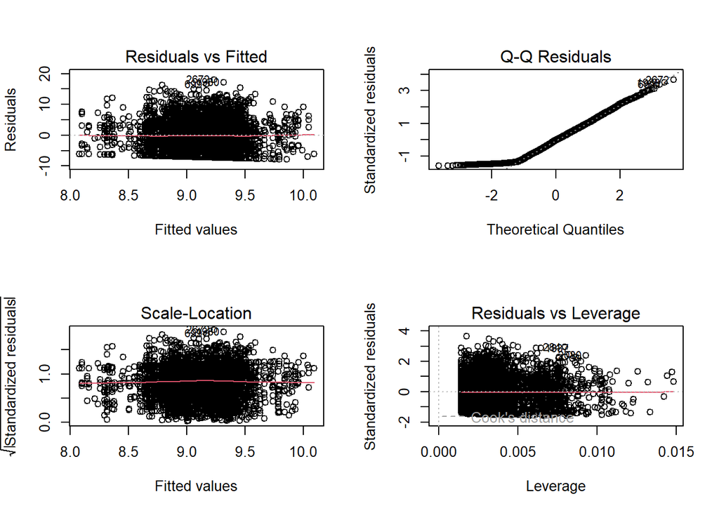

Показатель VIF оказался равен 1 для все предикторов модели, мультиколлинеарности между ними нет.

Однако, к сожалению, наша модель не удовлетворяет допущениям для проведения ANOVA, поэтому мы используем непараметрический тест, а именно проведем серию попарных сравнений с помощью тест Вилкоксона, основанного на сравнении медиан групп.

### Попарный тест Вилкоксона

```r
pairwise.wilcox.test(x = work_data$insulin_level, g = work_data$ethnicity)$p.value
```

```
##          Asian     Black Hispanic    Other
## Black        1        NA       NA       NA
## Hispanic     1 1.0000000       NA       NA
## Other        1 0.8075869        1       NA
## White        1 1.0000000        1 0.757925
```

```r
pairwise.wilcox.test(x = work_data$insulin_level, g = work_data$education_level)$p.value
```

```
##              Graduate Highschool No formal
## Highschool          1         NA        NA
## No formal           1          1        NA
## Postgraduate        1          1         1
```

```r
pairwise.wilcox.test(x = work_data$insulin_level, g = work_data$income_level)$p.value
```

```
##              High       Low Lower-Middle Middle
## Low             1        NA           NA     NA
## Lower-Middle    1 0.2550710           NA     NA
## Middle          1 1.0000000    0.9964487     NA
## Upper-Middle    1 0.3920466    1.0000000      1
```

```r
pairwise.wilcox.test(x = work_data$insulin_level, g = work_data$employment_status)$p.value
```

```
##             Employed   Retired   Student
## Retired    1.0000000        NA        NA
## Student    0.7491276 0.7491276        NA
## Unemployed 1.0000000 1.0000000 0.7491276
```

Ни для одного из 4х предикторов не было выявлено значимого влияния на уровень инсулина. Уровень инсулина в крови не зависит от социальных факторов.

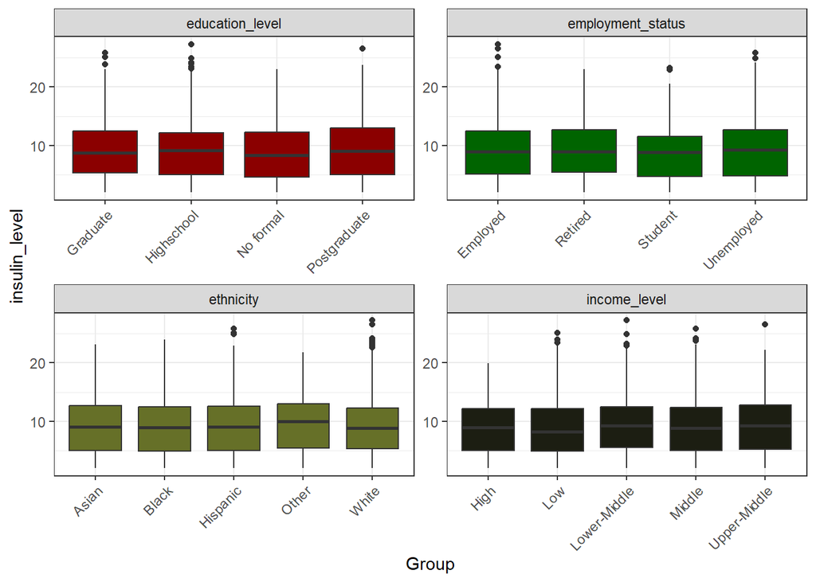

# Модели

## Модель 1

## Модель 2